# Untitled

Zehra Hacioglu, Arzum Gursoy, Omer Sen, Olgun Aslan

23 01 2021

KAGGLE VERİLERİNİN KEŞFİ

Bu proje ile 2017 yılı Kaggle Veri Bilimi Anket sonuçları ile profosyonellerin günlük yaşantılarında kullanmış oldukları dil ve yöntemlerin keşfedilmesi amaçlanmıştır. Paket içeriği 5 ayrı dosyadan oluşmaktadır. Bu projede kullanılan dosya anket sonuçlarının bulunduğu rawMCData veri setidir. Veri seti 16.716 satır ve 228 sütundan oluşmaktadır. Her bir sütun katılımcıların sorulan sorulara verdikleri cevapları içermektedir.

İlk Adım: kullanılacak paketler ve veri setinin yüklenmesi.

```r
library(readr)
library(tidyverse)
library(dplyr)
library(ggplot2)
```

```r
rawMCData <- read.csv("C:/Users/Zehra/Desktop/multipleChoiceResponses.csv", stringsAsFactors = T, header = T)
attach(rawMCData)
```

```r
head(rawMCData, n = 5)
```

|  | GenderSelect | Country | Age | EmploymentStatus | StudentStatus | LearningDataScience | CodeWriter | CareerSwitcher | CurrentJobTitleSelect | TitleFit | CurrentEmployerType | MLToolNextYearSelect | MLMethodNextYearSelect | LanguageRecommendationSelect | PublicDatasetsSelect | LearningPlatformSelect | LearningPlatformUsefulnessArxiv | LearningPlatformUsefulnessBlogs | LearningPlatformUsefulnessCollege | LearningPlatformUsefulnessCompany | LearningPlatformUsefulnessConferences | LearningPlatformUsefulnessFriends | LearningPlatformUsefulnessKaggle | LearningPlatformUsefulnessNewsletters | LearningPlatformUsefulnessCommunities | LearningPlatformUsefulnessDocumentation | LearningPlatformUsefulnessCourses | LearningPlatformUsefulnessProjects | LearningPlatformUsefulnessPodcasts | … |
| --- | --- | --- | --- | --- | --- | --- | --- | --- | --- | --- | --- | --- | --- | --- | --- | --- | --- | --- | --- | --- | --- | --- | --- | --- | --- | --- | --- | --- | --- | --- |
| 1 | Non-binary, genderqueer, or gender non-conforming |  | NA | Employed full-time |  |  | Yes |  | DBA/Database Engineer | Fine | Employed by a company that doesn't perform advanced analytics,Employed by non-profit or NGO | SAS Base | Random Forests | F# | Dataset aggregator/platform (i.e. Socrata/Kaggle Datasets/data.world/etc.),University/Non-profit research group websites,Other | College/University,Conferences,Podcasts,Trade book |  |  |  |  | Very useful |  |  |  |  |  |  |  | Very useful | … |
| 2 | Female | United States | 30 | Not employed, but looking for work |  |  |  |  |  |  |  | Python | Random Forests | Python | Dataset aggregator/platform (i.e. Socrata/Kaggle Datasets/data.world/etc.) | Kaggle |  |  |  |  |  |  | Somewhat useful |  |  |  |  |  |  | … |
| 3 | Male | Canada | 28 | Not employed, but looking for work |  |  |  |  |  |  |  | Amazon Web services | Deep learning | R | Dataset aggregator/platform (i.e. Socrata/Kaggle Datasets/data.world/etc.) | Arxiv,College/University,Kaggle,Online courses,YouTube Videos | Very useful |  | Somewhat useful |  |  |  | Somewhat useful |  |  |  | Very useful |  |  | … |
| 4 | Male | United States | 56 | Independent contractor, freelancer, or self-employed |  |  | Yes |  | Operations Research Practitioner | Poorly | Self-employed | TensorFlow | Neural Nets | Python | I collect my own data (e.g. web-scraping) | Blogs,College/University,Conferences,Friends network,Official documentation,Online courses,Personal Projects |  | Very useful | Very useful |  | Very useful | Very useful |  |  |  | Very useful | Very useful | Very useful |  | … |
| 5 | Male | Taiwan | 38 | Employed full-time |  |  | Yes |  | Computer Scientist | Fine | Employed by a company that doesn't perform advanced analytics | TensorFlow | Text Mining | Python | GitHub | Arxiv,Conferences,Kaggle,Textbook | Very useful |  |  |  | Somewhat useful |  | Somewhat useful |  |  |  |  |  |  | … |

|  | GenderSelect <fct> | Country <fct> | Age <int> |  |
| --- | --- | --- | --- | --- |
| 1 | Non-binary, genderqueer, or gender non-conforming |  | NA |  |
| 2 | Female | United States | 30 |  |
| 3 | Male | Canada | 28 |  |
| 4 | Male | United States | 56 |  |
| 5 | Male | Taiwan | 38 |  |

5 rows | 1-4 of 229 columns

İlk olarak katılımcıların yaşlarını gösteren bir histogram çizilsin.

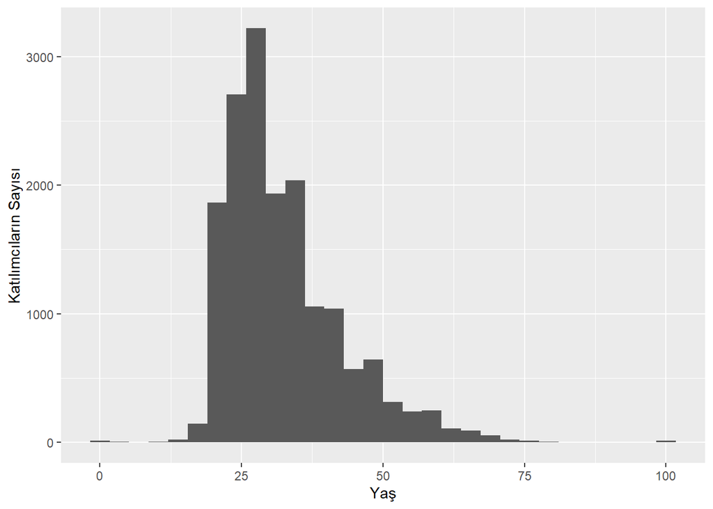

```r
ggplot(rawMCData, aes(Age, fill = Age)) +
  geom_histogram() +
  xlab("Yaş") +
  ylab("Katılımcıların Sayısı")
```

```r
median(Age, na.rm = TRUE)
```

```
## [1] 30
```

Histogram grifiğine göre katılımcıların yaş aralığı en çok 20-30 aralığındadır.

Aşağıda ki fonksiyon istenilen değişken için özet bilgileri veren bir fonksiyondur. Bu fonksiyon ile ilgili değişkenin her bir faktörü için yüzdelik ve miktar hesaplamaları gerçekleştirilecektir.

```r
chooseOne = function(question, filteredData = rawMCData){

  filteredData %>%
    filter(!UQ(sym(question)) == "") %>%
    group_by_(question) %>%
    summarise(count = n()) %>%
    mutate(percent = (count / sum(count)) * 100) %>%
    arrange(desc(count))

}
```

```r
gender <- chooseOne("GenderSelect")
gender
```

| GenderSelect | count | percent |
| --- | --- | --- |
| Male | 13610 | 81.8843632 |
| Female | 2778 | 16.7137958 |
| A different identity | 159 | 0.9566211 |
| Non-binary, genderqueer, or gender non-conforming | 74 | 0.4452199 |

| GenderSelect <fct> | count <int> | percent <dbl> |  |  |
| --- | --- | --- | --- | --- |
| Male | 13610 | 81.8843632 |  |  |
| Female | 2778 | 16.7137958 |  |  |
| A different identity | 159 | 0.9566211 |  |  |
| Non-binary, genderqueer, or gender non-conforming | 74 | 0.4452199 |  |  |

4 rows

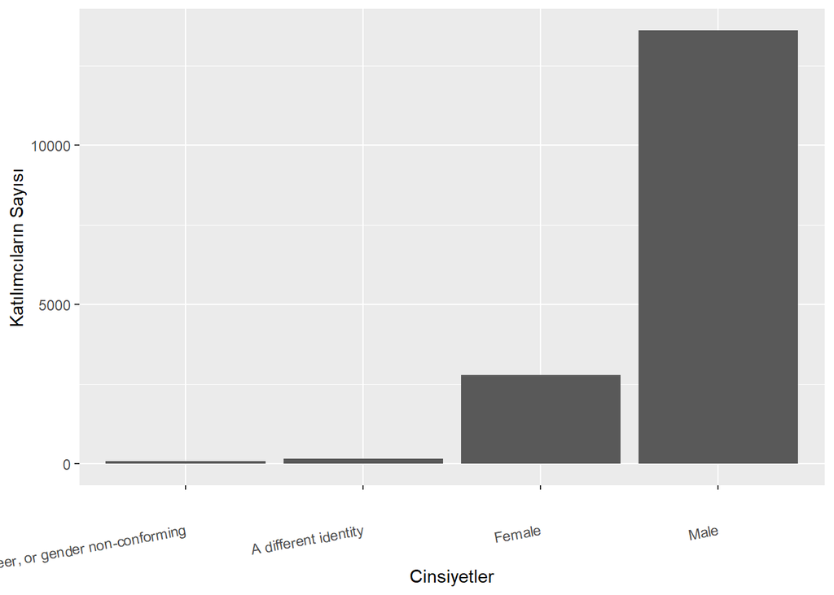

```r
ggplot(chooseOne("GenderSelect"),aes(x = reorder(GenderSelect, count), y = count)) +
  geom_bar(stat = "identity") +
  theme(axis.text.x = element_text(angle = 10,
                                   vjust = 0.5,
                                   hjust = 1))+
  xlab("Cinsiyetler")+
  ylab("Katılımcıların Sayısı")
```

İstatistikler ve grafik sonuçlarına göre rawMCData veri setinin %81,8 kadar büyük kısmını erkek katılımcılar oluşturmaktadır.

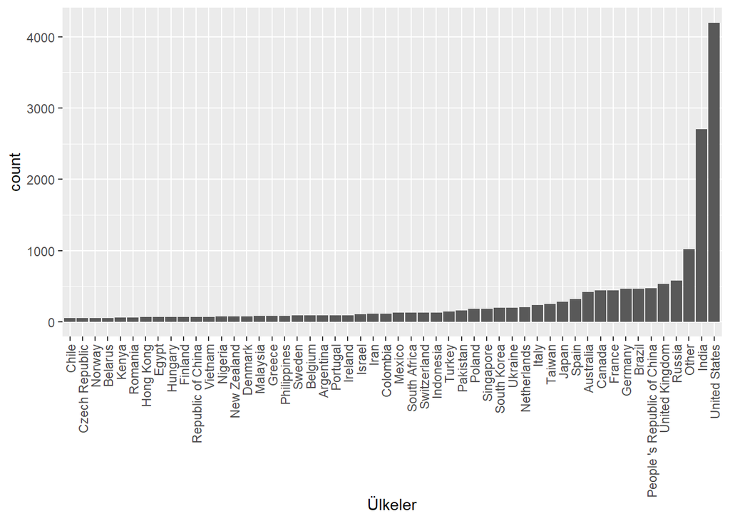

```r
ggplot(chooseOne("Country"),aes(x = reorder(Country, count), y = count)) +
  geom_bar(stat = "identity") +
  theme(axis.text.x = element_text(angle = 90,
                                   vjust = 0.5,
                                   hjust = 1))+
  xlab("Ülkeler")
```

```r
head(chooseOne("Country") , n = 5)
```

| Country | count | percent |
| --- | --- | --- |
| United States | 4197 | 25.290750 |
| India | 2704 | 16.294064 |
| Other | 1023 | 6.164507 |
| Russia | 578 | 3.482977 |
| United Kingdom | 535 | 3.223863 |

| Country <fct> | count <int> | percent <dbl> |  |  |
| --- | --- | --- | --- | --- |
| United States | 4197 | 25.290750 |  |  |
| India | 2704 | 16.294064 |  |  |
| Other | 1023 | 6.164507 |  |  |
| Russia | 578 | 3.482977 |  |  |
| United Kingdom | 535 | 3.223863 |  |  |

5 rows

Yukarıdaki grafik katılımcıların yaşadıkları ülkelerin artan sıraya göre grafiğini göstermektedir. Katılımcıların en çok katılım gösterdikleri ilk 5 ülke %25.2 oranında Birleşik Devletler, %16.2 oranında Hindistan, %6.1 oranında diğer ülkeler, %3.4 oranında Rusya ve son olarak %3.2 oranında Birleşik Krallık olacak şekilde bir sıralamaya sahiptir.

En çok katılımın gerçekleştiği 5 ülke filtrelenerek ve yeni bir veri setine atansın ve bu yeni veri seti ile en çok katılımın sağlandığı 5 ülkenin yaş aralıkları grafik ile gösterilsin.

```r
newData <- rawMCData%>%
  filter(Country == c("United States","India","Other","Russia","United Kingdom"))
```

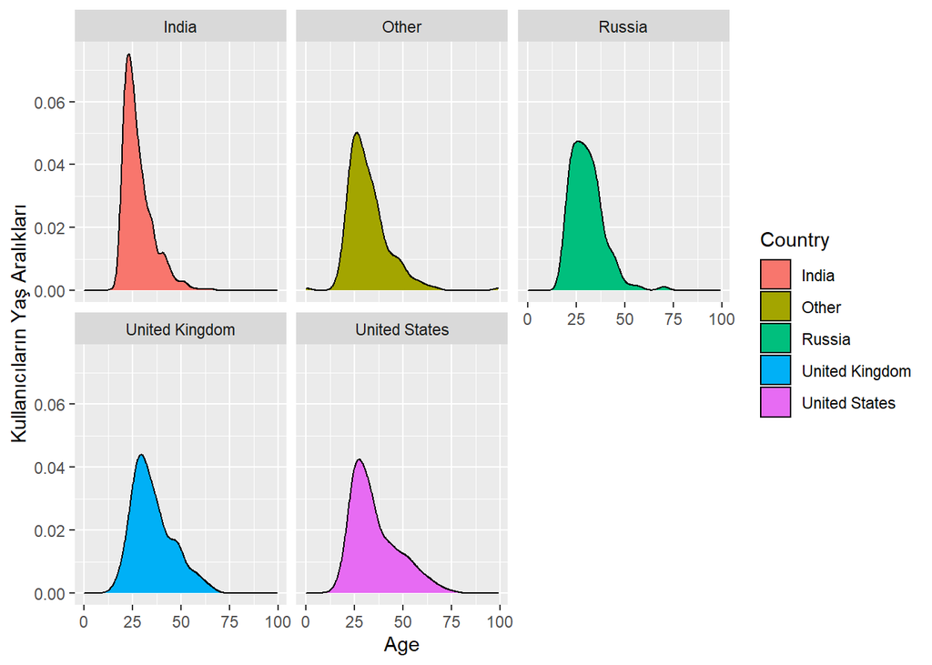

```r
ggplot(newData, aes(x = Age, fill = Country)) +
  geom_density() +
  facet_wrap(~Country) +
  ylab("Kullanıcıların Yaş Aralıkları")
```

Yaş aralığı en geniş olan grafik Birşekik Devletler’e aitken Hindistan diğer ülkelere kıyasla daha dar ve genç bir aralığa sahiptir. Bunların yanı sıra yaş aralığının en çok ABD ve Rusya’da olduğu görülmektedir.

Katılımcıların çalışma durumları nedir?

```r
chooseOne("EmploymentStatus")
```

| EmploymentStatus | count | percent |
| --- | --- | --- |
| Employed full-time | 10897 | 65.1890404 |
| Not employed, but looking for work | 2110 | 12.6226370 |
| Independent contractor, freelancer, or self-employed | 1330 | 7.9564489 |
| Not employed, and not looking for work | 924 | 5.5276382 |
| Employed part-time | 917 | 5.4857621 |
| I prefer not to say | 420 | 2.5125628 |
| Retired | 118 | 0.7059105 |

| EmploymentStatus <fct> | count <int> | percent <dbl> |  |  |
| --- | --- | --- | --- | --- |
| Employed full-time | 10897 | 65.1890404 |  |  |
| Not employed, but looking for work | 2110 | 12.6226370 |  |  |
| Independent contractor, freelancer, or self-employed | 1330 | 7.9564489 |  |  |
| Not employed, and not looking for work | 924 | 5.5276382 |  |  |
| Employed part-time | 917 | 5.4857621 |  |  |
| I prefer not to say | 420 | 2.5125628 |  |  |
| Retired | 118 | 0.7059105 |  |  |

7 rows

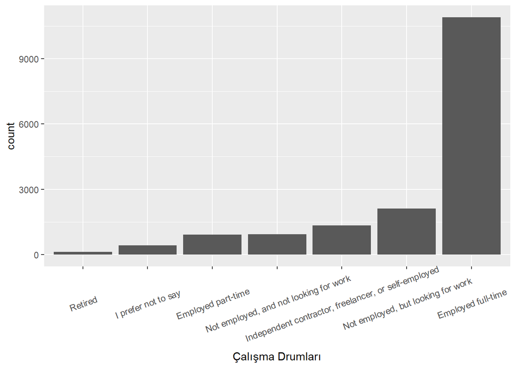

```r
ggplot(chooseOne("EmploymentStatus"), aes(x = reorder(EmploymentStatus,count), y = count))+
  geom_bar(stat = "identity")+
  theme(axis.text.x = element_text(angle = 20,
                                   vjust = 0.6)) +
  xlab("Çalışma Drumları")
```

Ankete katılanların %65’i tam zamanlı bir işte çalışmaktadır, %12.6’sı çalışmıyor fakat iş arıyor. Genel olarak katılımcıların %78.5’si çalışıyor, %18.3’i çalışmıyor, %2.5’i çalışma durumunu belirtmek istemiyor ve %0.7’si ise emeklidir.

Çalışma durumu ile yaş değişkenleri arasındaki ilişki kontrolünün yapılması.Katılımcıların çalışma durumları “EmploymentStatus” kolonunda yer almaktadır.

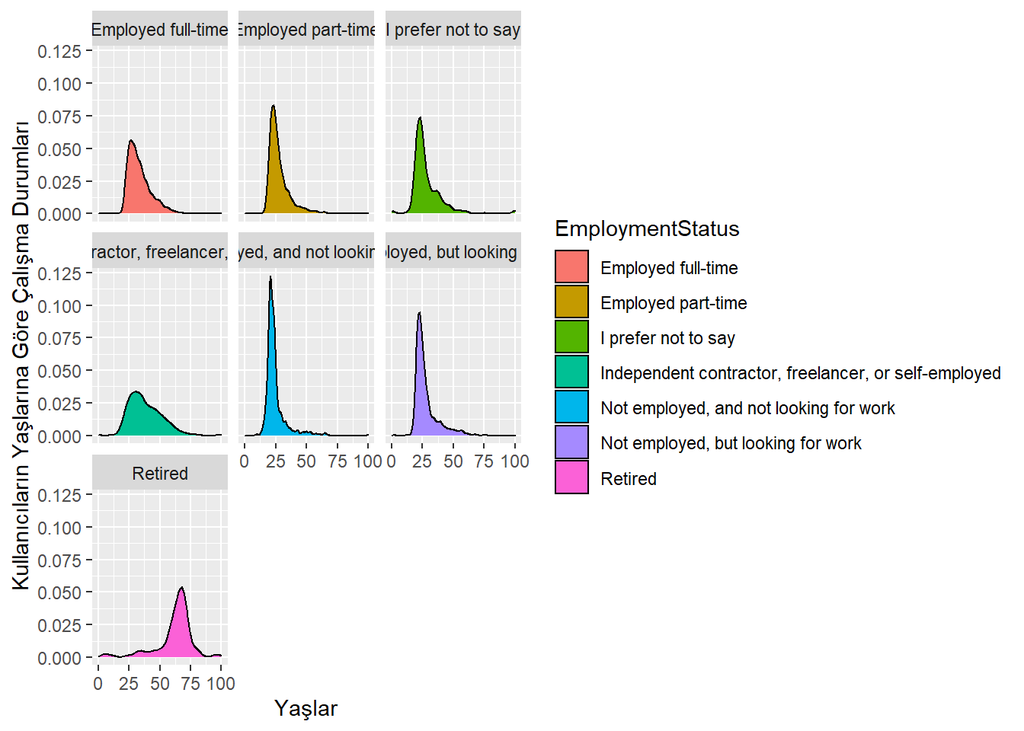

```r
ggplot(rawMCData, aes(x = Age, fill = EmploymentStatus)) +
  geom_density() +
  facet_wrap(~EmploymentStatus)+
  xlab("Yaşlar") +
  ylab("Kullanıcıların Yaşlarına Göre Çalışma Durumları")
```

Anketörler, çalışma durumlarını “çalışmıyorum fakat iş arıyorum”, “çalışmıyorum ve iş aramıyorum” ve “çalışma durumumu belirtmek istemiyorum” olarak cevaplayan katılımcılara yüksek dereceli bir okulda okuyup okumadıklarını sordu.Katılımcıların bu soruya verdikleri cevaplar “StudentStatus” kolonunda yer almaktadır. Verilen cevaplara göre katılımcıların eğitim seviyeleri belirlenecektir.

```r
chooseOne("StudentStatus")
```

| StudentStatus | count | percent |
| --- | --- | --- |
| Yes | 981 | 76.64062 |
| No | 299 | 23.35938 |

| StudentStatus <fct> | count <int> | percent <dbl> |  |  |
| --- | --- | --- | --- | --- |
| Yes | 981 | 76.64062 |  |  |
| No | 299 | 23.35938 |  |  |

2 rows

İstatistikler ankete katılanların %76.64’ünün yüksek dereceli bir okulda eğitim aldıklarını söylemektedir.

Katılımcılara veri bilimi becerilerini geliştirmeye odaklı olup olmadıkları sorulmuştur.

```r
chooseOne("LearningDataScience")
```

| LearningDataScience | count | percent |
| --- | --- | --- |
| Yes, I'm focused on learning mostly data science skills | 800 | 62.305296 |
| Yes, but data science is a small part of what I'm focused on learning | 429 | 33.411215 |
| No, I am not focused on learning data science skills | 55 | 4.283489 |

| LearningDataScience <fct> | count <int> | percent <dbl> |  |
| --- | --- | --- | --- |
| Yes, I'm focused on learning mostly data science skills | 800 | 62.305296 |  |
| Yes, but data science is a small part of what I'm focused on learning | 429 | 33.411215 |  |
| No, I am not focused on learning data science skills | 55 | 4.283489 |  |

3 rows

Katılımcıların %62’si veri bilimi becerilerini geliştirmeye odaklandıklarını söylemektedir.

Anketörlerin, ne kadar süredir veri bilimi ile ilgilendikleri sorusuna katılımcıların vermiş oldukları cevaplar aşağıdaki gibir.

```r
lds_time <- chooseOne("LearningDataScienceTime")
lds_time
```

| LearningDataScienceTime | count | percent |
| --- | --- | --- |
| < 1 year | 2093 | 48.1260060 |
| 1-2 years | 1566 | 36.0082778 |
| 3-5 years | 540 | 12.4166475 |
| 5-10 years | 106 | 2.4373419 |
| 15+ years | 30 | 0.6898138 |
| 10-15 years | 14 | 0.3219131 |

| LearningDataScienceTime <fct> | count <int> | percent <dbl> |  |  |
| --- | --- | --- | --- | --- |
| < 1 year | 2093 | 48.1260060 |  |  |
| 1-2 years | 1566 | 36.0082778 |  |  |
| 3-5 years | 540 | 12.4166475 |  |  |
| 5-10 years | 106 | 2.4373419 |  |  |
| 15+ years | 30 | 0.6898138 |  |  |
| 10-15 years | 14 | 0.3219131 |  |  |

6 rows

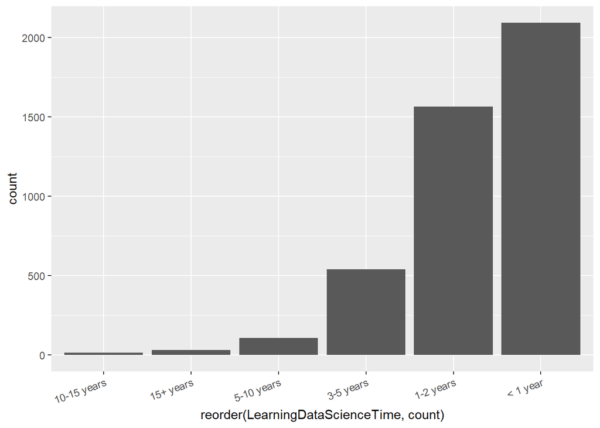

```r
ggplot(chooseOne("LearningDataScienceTime"),aes(x = reorder(LearningDataScienceTime, count), y = count)) +
  geom_bar(stat = "identity") +
  theme(axis.text.x = element_text(angle = 20,
                                   vjust = 1,
                                   hjust = 1))
```

İstatistikler, katılımcıların %84 gibi büyük bir çoğunluğunun 2 yıldan kısa bir süredir veri bilimi ile ilgilendiklerini göstermektedir.

```r
chooseOne("EmploymentStatus")
```

| EmploymentStatus | count | percent |
| --- | --- | --- |
| Employed full-time | 10897 | 65.1890404 |
| Not employed, but looking for work | 2110 | 12.6226370 |
| Independent contractor, freelancer, or self-employed | 1330 | 7.9564489 |
| Not employed, and not looking for work | 924 | 5.5276382 |
| Employed part-time | 917 | 5.4857621 |
| I prefer not to say | 420 | 2.5125628 |
| Retired | 118 | 0.7059105 |

| EmploymentStatus <fct> | count <int> | percent <dbl> |  |  |
| --- | --- | --- | --- | --- |
| Employed full-time | 10897 | 65.1890404 |  |  |
| Not employed, but looking for work | 2110 | 12.6226370 |  |  |
| Independent contractor, freelancer, or self-employed | 1330 | 7.9564489 |  |  |
| Not employed, and not looking for work | 924 | 5.5276382 |  |  |
| Employed part-time | 917 | 5.4857621 |  |  |
| I prefer not to say | 420 | 2.5125628 |  |  |
| Retired | 118 | 0.7059105 |  |  |

7 rows

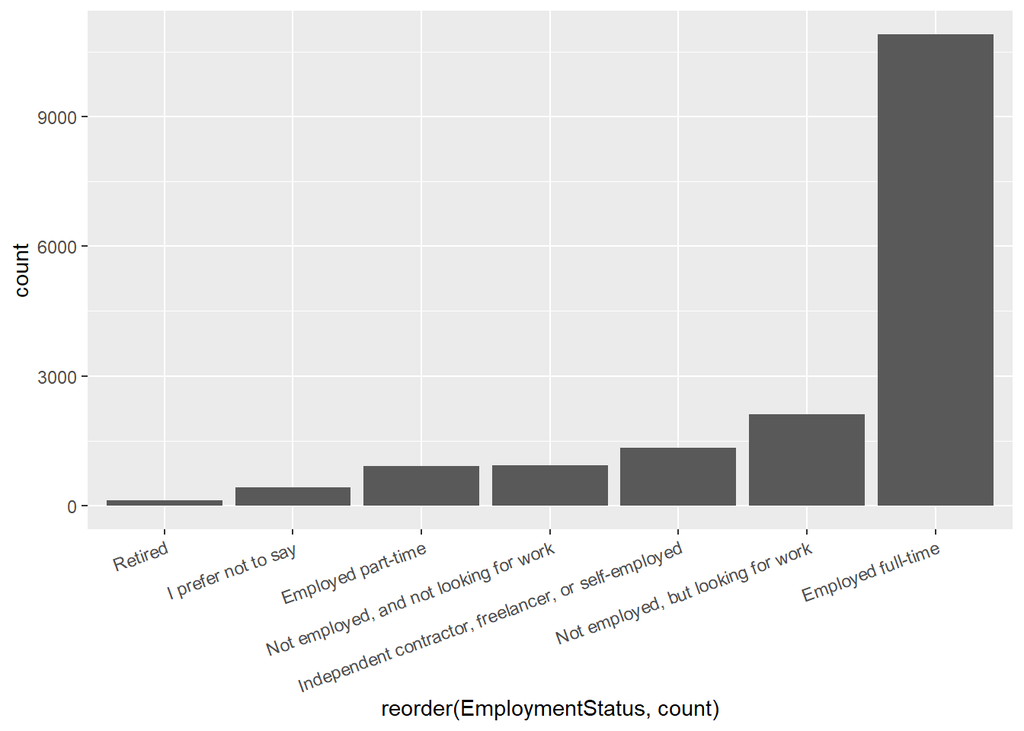

```r
ggplot(chooseOne("EmploymentStatus"),aes(x = reorder(EmploymentStatus, count), y = count)) +
  geom_bar(stat = "identity") +
  theme(axis.text.x = element_text(angle = 20,
                                   vjust = 1,
                                   hjust = 1))
```

Bu ankete katılım sağlayanlara günlük hayatta kullanmış oldukları araçların neler olduğu sorulmuştur.

```r
head(chooseOne("HardwarePersonalProjectsSelect"), n = 5)
```

| HardwarePersonalProjectsSelect | count | percent |
| --- | --- | --- |
| Basic laptop (Macbook) | 1713 | 40.72753 |
| Gaming Laptop (Laptop + CUDA capable GPU) | 427 | 10.15216 |
| Laptop + Cloud service (AWS, Azure, GCE ...) | 313 | 7.44175 |
| Traditional Workstation | 304 | 7.22777 |
| Laptop or Workstation and local IT supported servers | 268 | 6.37185 |

| HardwarePersonalProjectsSelect <fct> | count <int> | percent <dbl> |  |  |
| --- | --- | --- | --- | --- |
| Basic laptop (Macbook) | 1713 | 40.72753 |  |  |
| Gaming Laptop (Laptop + CUDA capable GPU) | 427 | 10.15216 |  |  |
| Laptop + Cloud service (AWS, Azure, GCE ...) | 313 | 7.44175 |  |  |
| Traditional Workstation | 304 | 7.22777 |  |  |
| Laptop or Workstation and local IT supported servers | 268 | 6.37185 |  |  |

5 rows

Yukarıdaki tablo katılımcıların günlük hayatlarında kullandıkları araçları göstermektedir. Kullanıcıların %40.7’si dizüstü bilgisayar(Macbook), %10.1’i oyun bilgisayarı, %7.4’ü dizüstü bilgisayar ve bulut hizmeti, %7.2’si iş istasyonu (teknik) bilgisayarı, %6.3’ü dizüstü veya iş istasyonu ve yerel BT destekli sunucuları kullandıklarını söylediler. Genel olarak çoğunluğun %40.7 oranında dizüstü bilgisayar kullandıkları saptanmıştır.

```r
chooseOne("LanguageRecommendationSelect")
```

| LanguageRecommendationSelect | count | percent |
| --- | --- | --- |
| Python | 6941 | 63.11147481 |
| R | 2643 | 24.03164212 |
| SQL | 385 | 3.50063648 |
| C/C++/C# | 307 | 2.79141662 |
| Matlab | 238 | 2.16402982 |
| Java | 138 | 1.25477360 |
| Scala | 94 | 0.85470085 |
| SAS | 88 | 0.80014548 |
| Other | 85 | 0.77286779 |
| Julia | 30 | 0.27277687 |

[output cut: 3 more lines]

| LanguageRecommendationSelect <fct> | count <int> | percent <dbl> |  |  |
| --- | --- | --- | --- | --- |
| Python | 6941 | 63.11147481 |  |  |
| R | 2643 | 24.03164212 |  |  |
| SQL | 385 | 3.50063648 |  |  |
| C/C++/C# | 307 | 2.79141662 |  |  |
| Matlab | 238 | 2.16402982 |  |  |
| Java | 138 | 1.25477360 |  |  |
| Scala | 94 | 0.85470085 |  |  |
| SAS | 88 | 0.80014548 |  |  |
| Other | 85 | 0.77286779 |  |  |
| Julia | 30 | 0.27277687 |  |  |

1-10 of 13 rows

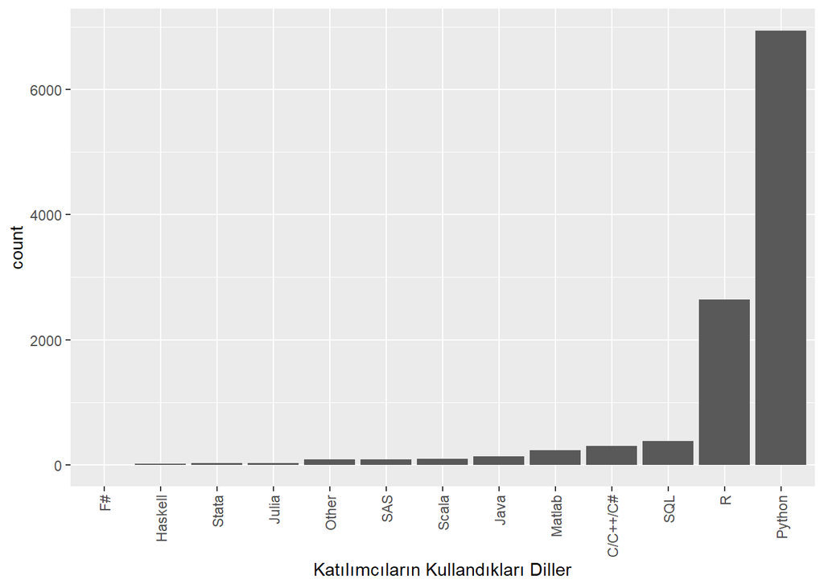

```r
ggplot(chooseOne("LanguageRecommendationSelect"),aes(x = reorder(LanguageRecommendationSelect, count), y = count)) +
  geom_bar(stat = "identity") +
  theme(axis.text.x = element_text(angle = 90,
                                   vjust = 0.5,
                                   hjust = 1))+
  xlab("Katılımcıların Kullandıkları Diller")
```

Görüldüğü üzere katılımcıların %63 gibi büyük bir kısmı veri analizleri sırasında Python’ı tercih ediyor. R ise %24 kullanım oranıyla Python’dan sonra en çok tercih edilen dil oluyor.

Sonuç olarak istatistiklere göre kullanıcıların en çok kullandıkları araç %40.7 oranıyla dizüstü bilgisayar(Macbook) ve en çok kullandıkları dil %63 oranıyla Python oluyor.